# IE360 Project Report

# Assumption and Modeling Approach

#### From now on, different linear regression models will be implemented only for the production data at 12 pm. After the selection of most suitable model according to the test results, we will train the whole data and make predictions. Training data will cover the timeline from March 1, 2022 to June 1, 2022 and the rest is for test. Since, prediction will be made for the month June, keeping the past productions would decrease the accuracy of our model. For model selection, R^2 does not give insightful information. Instead, focusing on WMAPE is critical.

#### For the first model, all the variables introduced above are used and WMAPE is computed.

```
Call:
lm(formula = scaledprod ~ . - date - datetime - hour - capacity -
    production, data = na.omit(training_Data))

Residuals:
     Min       1Q   Median       3Q      Max
-0.41222 -0.04855  0.01092  0.06514  0.23325

Coefficients:
                    Estimate Std. Error t value Pr(>|t|)
(Intercept)       -0.6166194  1.8608522  -0.331    0.742
CLL               -0.0536312  0.0387450  -1.384    0.173
DSWRF             -0.0104231  0.0069366  -1.503    0.139
RELH              -0.0544037  0.0811687  -0.670    0.506
TEMP               0.0814152  0.4208383   0.193    0.847
DSWRF_above        0.0025311  0.0025082   1.009    0.318
TEMP_above         0.0001543  0.0003982   0.387    0.700
RELH_above         0.0013728  0.0046054   0.298    0.767
CLL_above         -0.0003155  0.0034575  -0.091    0.928
CLL_lag1           0.0248030  0.0245230   1.011    0.317
RELH_lag1          0.0765488  0.0675422   1.133    0.263
DSWRF_lag1         0.0042843  0.0058482   0.733    0.467
TEMP_lag1         -0.0793861  0.4542012  -0.175    0.862
CLL_lag2          -0.0145021  0.0142179  -1.020    0.313
RELH_lag2         -0.0512462  0.0464823  -1.102    0.276
DSWRF_lag2        -0.0036858  0.0037407  -0.985    0.329
TEMP_lag2         -0.2069335  0.3091289  -0.669    0.506
CLL_lag3           0.0584600  0.0373219   1.566    0.124
RELH_lag3          0.0262410  0.0365831   0.717    0.477
DSWRF_lag3         0.0032439  0.0124173   0.261    0.795
TEMP_lag3          0.3632794  0.2520738   1.441    0.156
CLL_lag4          -0.0489312  0.0308684  -1.585    0.119
RELH_lag4          0.0172291  0.0264845   0.651    0.518
DSWRF_lag4        -0.0001272  0.0132390  -0.010    0.992
TEMP_lag4         -0.1291376  0.1108156  -1.165    0.250
CLL_next1          0.0170804  0.0597317   0.286    0.776
RELH_next1        -0.0124483  0.0756391  -0.165    0.870
DSWRF_next1        0.0086518  0.0063968   1.353    0.182
TEMP_next1        -0.3232675  0.3755828  -0.861    0.394
CLL_next2          0.0565789  0.0704152   0.804    0.426
RELH_next2         0.0557254  0.0761600   0.732    0.468
DSWRF_next2        0.0022349  0.0062684   0.357    0.723
TEMP_next2         0.2829709  0.3442576   0.822    0.415
CLL_next3         -0.0430796  0.0395045  -1.090    0.281
RELH_next3        -0.0103550  0.0446555  -0.232    0.818
DSWRF_next3       -0.0040100  0.0032835  -1.221    0.228
TEMP_next3         0.0145715  0.1501158   0.097    0.923
CLL_mean11         0.0017892  0.0203834   0.088    0.930
RELH_mean11       -0.0173364  0.0583016  -0.297    0.767
RELH_l8h          -0.0265945  0.0234023  -1.136    0.261
scaledprod_lag72  -0.0825698  0.1030583  -0.801    0.427
scaledprod_lag96   0.0733445  0.1050392   0.698    0.488
scaledprod_lag120 -0.0779600  0.1075365  -0.725    0.472

Residual standard error: 0.1504 on 49 degrees of freedom
Multiple R-squared:  0.7117,	Adjusted R-squared:  0.4646
F-statistic: 2.881 on 42 and 49 DF,  p-value: 0.0002211
```

0.111534777553185

```
	Breusch-Godfrey test for serial correlation of order up to 46

data:  Residuals
LM test = 87.114, df = 46, p-value = 0.0002399
```

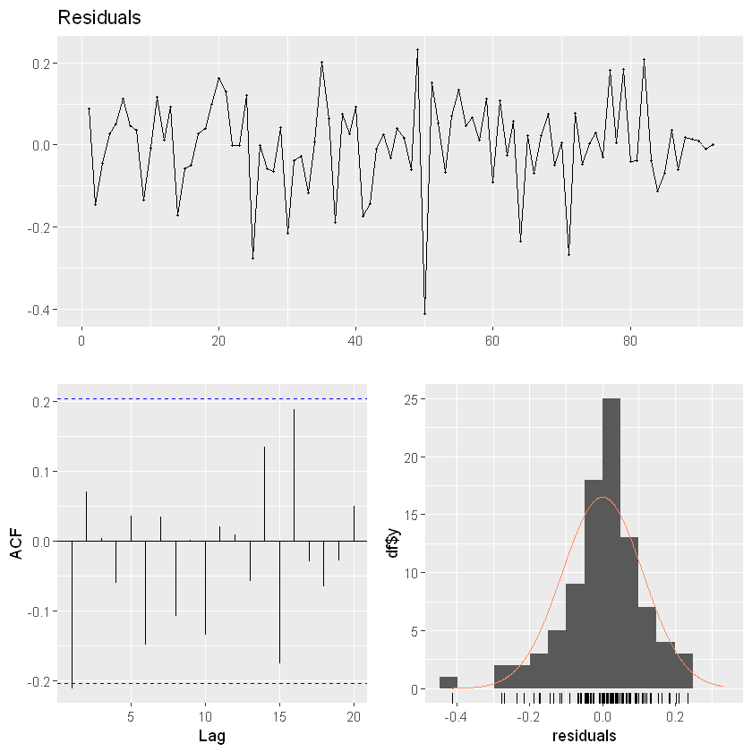

```r
fit <- lm(scaledprod ~.-date-datetime-hour-capacity-production, na.omit(training_Data))
summary(fit)
predicted=pmin(pmax(0,predict(fit,test_Data))*test_Data$capacity,test_Data$capacity)
WMAPE(test_Data$production, predicted)
checkresiduals(fit)
```

```
Call:
lm(formula = scaledprod ~ . - date - datetime - hour - capacity -
    production - TEMP - TEMP_lag1 - TEMP_lag2 - TEMP_lag3 - TEMP_lag4 -
    TEMP_above - RELH_next3 - TEMP_next1 - CLL_next1 - CLL_next2 -
    scaledprod_lag72 - CLL_lag2 - RELH_l8h - DSWRF_next2 - RELH_mean11 -
    production - CLL_lag1 - scaledprod_lag96 - scaledprod_lag120 -
    DSWRF_next3 - CLL - CLL_next3 - DSWRF_above - TEMP_above -
    RELH_above - CLL_above - DSWRF - DSWRF_lag1 - DSWRF_lag2 -
    DSWRF_lag3 - DSWRF_lag4, data = na.omit(training_Data))

Residuals:
     Min       1Q   Median       3Q      Max
-0.51443 -0.03433  0.02856  0.08990  0.26870

Coefficients:
              Estimate Std. Error t value Pr(>|t|)
(Intercept)  1.5500894  1.0467180   1.481  0.14266
RELH        -0.0416285  0.0314837  -1.322  0.18996
RELH_lag1    0.0633113  0.0310263   2.041  0.04468 *
RELH_lag2   -0.0233250  0.0236660  -0.986  0.32738
CLL_lag3     0.0161207  0.0154686   1.042  0.30056
RELH_lag3   -0.0172611  0.0210710  -0.819  0.41517
CLL_lag4    -0.0133123  0.0128419  -1.037  0.30311
RELH_lag4    0.0121107  0.0118895   1.019  0.31154
RELH_next1  -0.0083660  0.0258760  -0.323  0.74732
DSWRF_next1  0.0007513  0.0001974   3.805  0.00028 ***
RELH_next2   0.0142592  0.0160823   0.887  0.37800
TEMP_next2  -0.1133939  0.0558927  -2.029  0.04589 *
TEMP_next3   0.1092514  0.0565463   1.932  0.05698 .
CLL_mean11  -0.0030437  0.0041467  -0.734  0.46514
---
Signif. codes:  0 '***' 0.001 '**' 0.01 '*' 0.05 '.' 0.1 ' ' 1

Residual standard error: 0.1668 on 78 degrees of freedom
Multiple R-squared:  0.436,	Adjusted R-squared:  0.342
F-statistic: 4.638 on 13 and 78 DF,  p-value: 7.592e-06
```

0.0975321848796311

```
	Breusch-Godfrey test for serial correlation of order up to 17

data:  Residuals
LM test = 12.128, df = 17, p-value = 0.7923
```

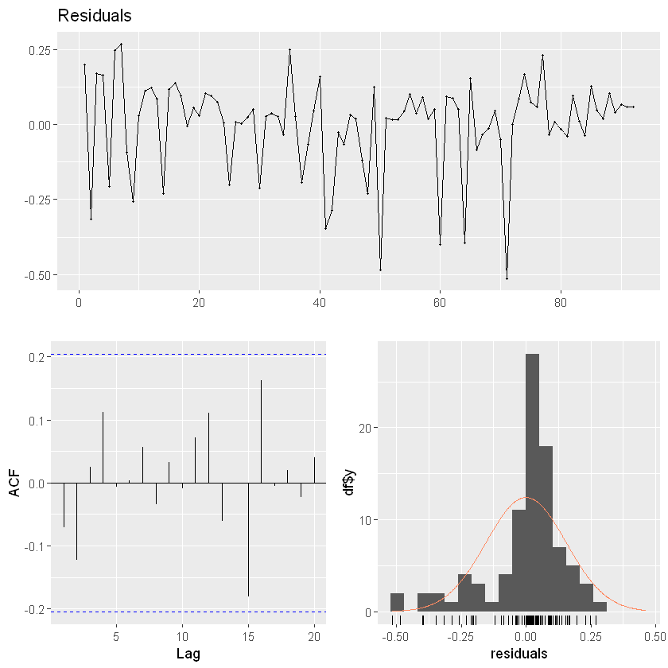

```r
fit <- lm(scaledprod ~.-date-datetime-hour-capacity-production-TEMP-TEMP_lag1-TEMP_lag2-TEMP_lag3-TEMP_lag4-TEMP_above-RELH_next3-TEMP_next1-CLL_next1-CLL_next2-scaledprod_lag72-CLL_lag2-RELH_l8h-DSWRF_next2-RELH_mean11-production-CLL_lag1-scaledprod_lag96-scaledprod_lag120-DSWRF_next3-CLL-CLL_next3-DSWRF_above-TEMP_above-RELH_above-CLL_above-DSWRF-DSWRF_lag1-DSWRF_lag2-DSWRF_lag3-DSWRF_lag4, na.omit(training_Data))
summary(fit)
predicted=pmin(pmax(0,predict(fit,test_Data))*test_Data$capacity,test_Data$capacity)
WMAPE(test_Data$production, predicted)
checkresiduals(fit)
```

#### ACF of residuals seems pretty good with no significant spikes. Besides, residuals have constant variance and mean around 0. Time series of residuals seem to show stationarity. Fitting residuals with arima model might give us usefull insights about the residual behaviour.

```r
arima.fit <- auto.arima(fit$residuals, trace = TRUE)
summary(arima.fit)
```

```
 ARIMA(2,0,2) with non-zero mean : -73.22277
 ARIMA(0,0,0) with non-zero mean : -79.52142
 ARIMA(1,0,0) with non-zero mean : -77.85248
 ARIMA(0,0,1) with non-zero mean : -78.00447
 ARIMA(0,0,0) with zero mean     : -81.6118
 ARIMA(1,0,1) with non-zero mean : -76.2102

 Best model: ARIMA(0,0,0) with zero mean

Series: fit$residuals
ARIMA(0,0,0) with zero mean

sigma^2 estimated as 0.02358:  log likelihood=41.83
AIC=-81.66   AICc=-81.61   BIC=-79.13

Training set error measures:
                      ME     RMSE       MAE MPE MAPE      MASE        ACF1
Training set 3.46326e-19 0.153571 0.1087258 100  100 0.7090038 -0.07098518
```

#### Residuals have simply white noise characteristics according to the ARIMA(0,0,0) model. Before finalizing the model selection, we will try to use ARIMA model for the production prediction. Here, WMAPE is computed by the training data.

```r
arima.fit <- auto.arima(training_Data[,scaledprod], trace = TRUE, max.p = 20,max.q = 20)
summary(arima.fit)
(sum(abs(arima.fit$residuals))/nrow(training_Data))/mean(training_Data$scaledprod)
```

```
 ARIMA(2,1,2) with drift         : -20.31947
 ARIMA(0,1,0) with drift         : 32.20514
 ARIMA(1,1,0) with drift         : 11.14332
 ARIMA(0,1,1) with drift         : Inf
 ARIMA(0,1,0)                    : 30.14645
 ARIMA(1,1,2) with drift         : Inf
 ARIMA(2,1,1) with drift         : -22.37311
 ARIMA(1,1,1) with drift         : Inf
 ARIMA(2,1,0) with drift         : -9.053327
 ARIMA(3,1,1) with drift         : Inf
 ARIMA(3,1,0) with drift         : -15.22603
 ARIMA(3,1,2) with drift         : Inf
 ARIMA(2,1,1)                    : -23.21047
 ARIMA(1,1,1)                    : -22.54609
 ARIMA(2,1,0)                    : -11.0185
 ARIMA(3,1,1)                    : -21.34853
 ARIMA(2,1,2)                    : -21.1295
 ARIMA(1,1,0)                    : 9.125692
 ARIMA(1,1,2)                    : -21.69532
 ARIMA(3,1,0)                    : -17.15878
 ARIMA(3,1,2)                    : -19.3852

 Best model: ARIMA(2,1,1)

Series: training_Data[, scaledprod]
ARIMA(2,1,1)

Coefficients:
          ar1      ar2      ma1
      -0.1585  -0.2179  -0.7962
s.e.   0.1354   0.1262   0.1086

sigma^2 estimated as 0.04201:  log likelihood=15.84
AIC=-23.68   AICc=-23.21   BIC=-13.63

Training set error measures:
                     ME      RMSE       MAE       MPE     MAPE      MASE
Training set 0.02910152 0.2004534 0.1521752 -5.348591 23.77433 0.8789199
                   ACF1
Training set -0.0043444
```

0.171909606447889

```
[1] "Model Outputs for hour =  5"

Call:
lm(formula = as.formula(fmla[h]), data = dt_train[[h]])

Residuals:
      Min        1Q    Median        3Q       Max
-0.155781 -0.028399 -0.006328  0.034472  0.098886

Coefficients:
             Estimate Std. Error t value Pr(>|t|)
(Intercept)  3.715066   2.369486   1.568  0.12645
RELH         0.060323   0.029786   2.025  0.05100 .
RELH_lag1   -0.056386   0.026486  -2.129  0.04082 *
RELH_lag2    0.015213   0.022070   0.689  0.49545
CLL_lag3     0.077666   0.088814   0.874  0.38818
RELH_lag3   -0.003890   0.035739  -0.109  0.91399
CLL_lag4     0.024877   0.078663   0.316  0.75381
RELH_lag4    0.002501   0.021762   0.115  0.90920
RELH_next1  -0.028590   0.021918  -1.304  0.20111
DSWRF_next1  0.522588   0.038350  13.627 4.18e-15 ***
RELH_next2   0.011398   0.010535   1.082  0.28713
TEMP_next2   0.026618   0.026787   0.994  0.32761
TEMP_next3  -0.038768   0.026236  -1.478  0.14898
CLL_mean11  -0.259525   0.082960  -3.128  0.00366 **
---
Signif. codes:  0 '***' 0.001 '**' 0.01 '*' 0.05 '.' 0.1 ' ' 1

Residual standard error: 0.06459 on 33 degrees of freedom
Multiple R-squared:  0.9484,	Adjusted R-squared:  0.9281
F-statistic: 46.65 on 13 and 33 DF,  p-value: < 2.2e-16

[1] "Model Outputs for hour =  6"

Call:
lm(formula = as.formula(fmla[h]), data = dt_train[[h]])

Residuals:
      Min        1Q    Median        3Q       Max
-0.198454 -0.041904  0.002395  0.043315  0.139806
```

[output cut: 8 more lines]

```
RELH_lag3    0.001016   0.010288   0.099   0.9215
CLL_lag4     0.003588   0.009568   0.375   0.7084
RELH_lag4   -0.001652   0.006550  -0.252   0.8014
RELH_next1   0.006041   0.005646   1.070   0.2870
DSWRF_next1  0.026362   0.001317  20.021  < 2e-16 ***
RELH_next2  -0.011532   0.002777  -4.153 6.62e-05 ***
TEMP_next2   0.069728   0.014917   4.674 8.64e-06 ***
TEMP_next3  -0.074265   0.016505  -4.500 1.74e-05 ***
CLL_mean11  -0.001465   0.002485  -0.590   0.5568
---
Signif. codes:  0 '***' 0.001 '**' 0.01 '*' 0.05 '.' 0.1 ' ' 1

Residual standard error: 0.06511 on 107 degrees of freedom
Multiple R-squared:  0.9431,	Adjusted R-squared:  0.9362
F-statistic: 136.5 on 13 and 107 DF,  p-value: < 2.2e-16
```

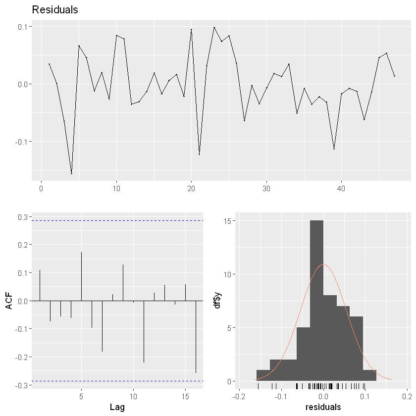

```
[1] "Model Outputs for hour =  7"

Call:
lm(formula = as.formula(fmla[h]), data = dt_train[[h]])

Residuals:
    Min      1Q  Median      3Q     Max
-0.5670 -0.1253 -0.0025  0.0834  0.7218

Coefficients:
              Estimate Std. Error t value Pr(>|t|)
(Intercept)  4.7079501  1.2838993   3.667 0.000311 ***
RELH         0.0415320  0.0154939   2.681 0.007931 **
RELH_lag1   -0.0219507  0.0265451  -0.827 0.409216
RELH_lag2   -0.0125690  0.0371585  -0.338 0.735507
CLL_lag3     0.0023692  0.0023979   0.988 0.324275
RELH_lag3    0.0263813  0.0285139   0.925 0.355915
CLL_lag4    -0.0008599  0.0014180  -0.606 0.544877
RELH_lag4   -0.0068727  0.0109133  -0.630 0.529537
RELH_next1  -0.0495263  0.0115462  -4.289 2.73e-05 ***
DSWRF_next1  0.0108539  0.0015300   7.094 1.94e-11 ***
RELH_next2   0.0226581  0.0074233   3.052 0.002563 **
TEMP_next2  -0.0013898  0.0525554  -0.026 0.978929
TEMP_next3  -0.0137537  0.0539201  -0.255 0.798913
CLL_mean11  -0.0065865  0.0034141  -1.929 0.055049 .
---
Signif. codes:  0 '***' 0.001 '**' 0.01 '*' 0.05 '.' 0.1 ' ' 1

Residual standard error: 0.2273 on 211 degrees of freedom
Multiple R-squared:  0.6063,	Adjusted R-squared:  0.582
F-statistic: 24.99 on 13 and 211 DF,  p-value: < 2.2e-16
```

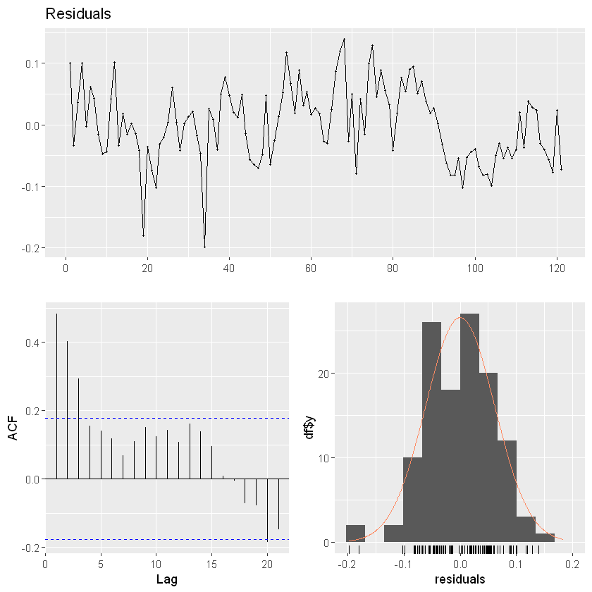

```
[1] "Model Outputs for hour =  8"

Call:
lm(formula = as.formula(fmla[h]), data = dt_train[[h]])

Residuals:
     Min       1Q   Median       3Q      Max
-0.50880 -0.08925  0.02228  0.09411  0.71618

Coefficients:
              Estimate Std. Error t value Pr(>|t|)
(Intercept)  6.4962642  1.0348241   6.278 1.93e-09 ***
RELH        -0.0303025  0.0099053  -3.059  0.00251 **
RELH_lag1    0.0415701  0.0114625   3.627  0.00036 ***
RELH_lag2   -0.0309963  0.0202229  -1.533  0.12684
CLL_lag3     0.0062393  0.0054910   1.136  0.25713
RELH_lag3   -0.0013743  0.0271215  -0.051  0.95963
CLL_lag4    -0.0073448  0.0045779  -1.604  0.11012
RELH_lag4    0.0122517  0.0142882   0.857  0.39216
RELH_next1   0.0030301  0.0099275   0.305  0.76050
DSWRF_next1  0.0065716  0.0007719   8.513 3.17e-15 ***
RELH_next2   0.0034264  0.0060665   0.565  0.57281
TEMP_next2  -0.0238206  0.0541018  -0.440  0.66018
TEMP_next3   0.0029212  0.0550958   0.053  0.95777
CLL_mean11  -0.0041874  0.0024423  -1.715  0.08790 .
---
Signif. codes:  0 '***' 0.001 '**' 0.01 '*' 0.05 '.' 0.1 ' ' 1

Residual standard error: 0.1772 on 211 degrees of freedom
Multiple R-squared:  0.7645,	Adjusted R-squared:   0.75
F-statistic:  52.7 on 13 and 211 DF,  p-value: < 2.2e-16
```

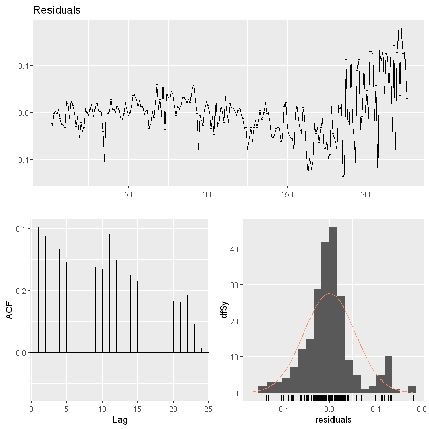

```
[1] "Model Outputs for hour =  9"

Call:
lm(formula = as.formula(fmla[h]), data = dt_train[[h]])

Residuals:
     Min       1Q   Median       3Q      Max
-0.71622 -0.04731  0.01835  0.09650  0.61297

Coefficients:
             Estimate Std. Error t value Pr(>|t|)
(Intercept)  5.799684   0.925834   6.264 2.07e-09 ***
RELH         0.002255   0.011120   0.203   0.8395
RELH_lag1   -0.010667   0.009984  -1.068   0.2866
RELH_lag2    0.019522   0.010851   1.799   0.0734 .
CLL_lag3     0.002406   0.006193   0.388   0.6981
RELH_lag3   -0.015519   0.015901  -0.976   0.3302
CLL_lag4    -0.006378   0.005082  -1.255   0.2109
RELH_lag4    0.005069   0.010196   0.497   0.6196
RELH_next1  -0.009825   0.015936  -0.616   0.5382
DSWRF_next1  0.001419   0.000194   7.311 5.41e-12 ***
RELH_next2   0.005838   0.009665   0.604   0.5465
TEMP_next2  -0.030766   0.053942  -0.570   0.5690
TEMP_next3   0.012112   0.054680   0.222   0.8249
CLL_mean11  -0.000302   0.002641  -0.114   0.9090
---
Signif. codes:  0 '***' 0.001 '**' 0.01 '*' 0.05 '.' 0.1 ' ' 1

Residual standard error: 0.1761 on 211 degrees of freedom
Multiple R-squared:  0.7734,	Adjusted R-squared:  0.7594
F-statistic: 55.39 on 13 and 211 DF,  p-value: < 2.2e-16
```

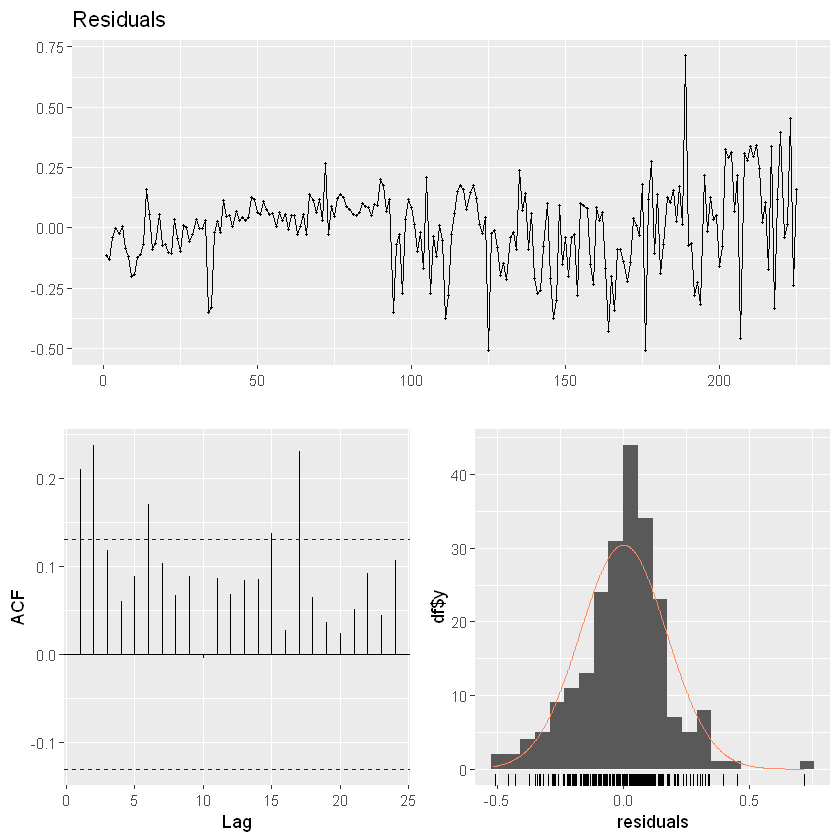

```
[1] "Model Outputs for hour =  10"

Call:
lm(formula = as.formula(fmla[h]), data = dt_train[[h]])

Residuals:
     Min       1Q   Median       3Q      Max
-0.72674 -0.05385  0.02774  0.08171  0.43348

Coefficients:
              Estimate Std. Error t value Pr(>|t|)
(Intercept)  5.1181782  0.9109360   5.619 6.04e-08 ***
RELH        -0.0109636  0.0190468  -0.576   0.5655
RELH_lag1   -0.0074813  0.0114511  -0.653   0.5143
RELH_lag2    0.0057533  0.0102075   0.564   0.5736
CLL_lag3     0.0091036  0.0066851   1.362   0.1747
RELH_lag3    0.0026421  0.0098369   0.269   0.7885
CLL_lag4    -0.0120416  0.0057010  -2.112   0.0358 *
RELH_lag4   -0.0028573  0.0064202  -0.445   0.6567
RELH_next1   0.0317280  0.0231978   1.368   0.1729
DSWRF_next1  0.0012437  0.0001831   6.792 1.10e-10 ***
RELH_next2  -0.0211051  0.0124891  -1.690   0.0925 .
TEMP_next2  -0.0211209  0.0542497  -0.389   0.6974
TEMP_next3   0.0047220  0.0550120   0.086   0.9317
CLL_mean11  -0.0008810  0.0025003  -0.352   0.7249
---
Signif. codes:  0 '***' 0.001 '**' 0.01 '*' 0.05 '.' 0.1 ' ' 1

Residual standard error: 0.176 on 211 degrees of freedom
Multiple R-squared:  0.7242,	Adjusted R-squared:  0.7073
F-statistic: 42.63 on 13 and 211 DF,  p-value: < 2.2e-16
```

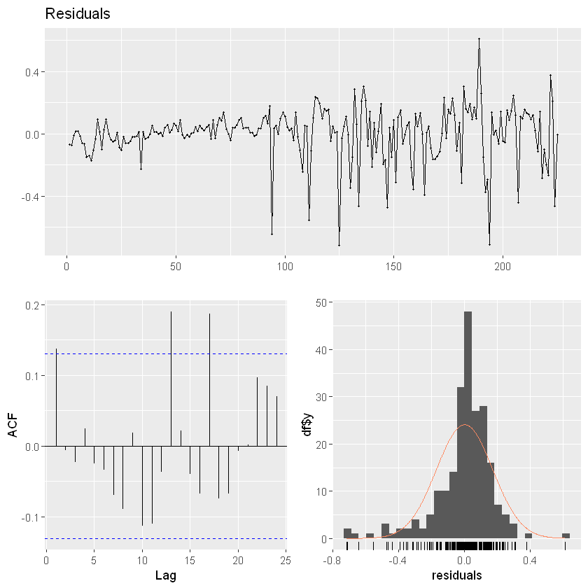

```
[1] "Model Outputs for hour =  11"

Call:
lm(formula = as.formula(fmla[h]), data = dt_train[[h]])

Residuals:
     Min       1Q   Median       3Q      Max
-0.53975 -0.04491  0.01170  0.07073  0.43304

Coefficients:
              Estimate Std. Error t value Pr(>|t|)
(Intercept)  4.1229783  0.7314783   5.637 5.52e-08 ***
RELH         0.0560815  0.0197265   2.843  0.00491 **
RELH_lag1   -0.0354736  0.0153863  -2.306  0.02211 *
RELH_lag2    0.0085570  0.0091547   0.935  0.35100
CLL_lag3     0.0101479  0.0061891   1.640  0.10257
RELH_lag3   -0.0073514  0.0080465  -0.914  0.36197
CLL_lag4    -0.0100458  0.0055833  -1.799  0.07341 .
RELH_lag4    0.0058681  0.0041493   1.414  0.15877
RELH_next1  -0.0344386  0.0191679  -1.797  0.07382 .
DSWRF_next1  0.0007644  0.0001371   5.574 7.56e-08 ***
RELH_next2   0.0048483  0.0102223   0.474  0.63578
TEMP_next2  -0.1391519  0.0420354  -3.310  0.00110 **
TEMP_next3   0.1267257  0.0425745   2.977  0.00326 **
CLL_mean11  -0.0046150  0.0019309  -2.390  0.01772 *
---
Signif. codes:  0 '***' 0.001 '**' 0.01 '*' 0.05 '.' 0.1 ' ' 1

Residual standard error: 0.1435 on 211 degrees of freedom
Multiple R-squared:  0.7732,	Adjusted R-squared:  0.7592
F-statistic: 55.33 on 13 and 211 DF,  p-value: < 2.2e-16
```

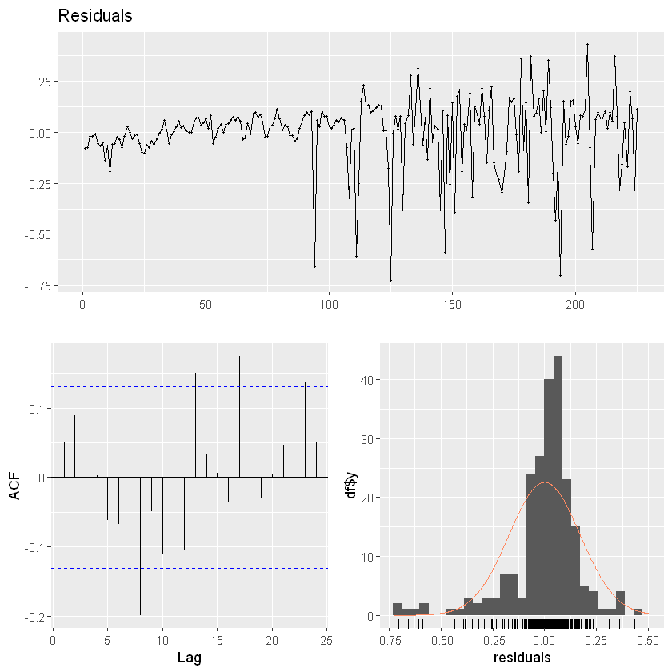

```
[1] "Model Outputs for hour =  12"

Call:
lm(formula = as.formula(fmla[h]), data = dt_train[[h]])

Residuals:
     Min       1Q   Median       3Q      Max
-0.55651 -0.05552  0.01707  0.06534  0.35301

Coefficients:
              Estimate Std. Error t value Pr(>|t|)
(Intercept)  4.0790641  0.7464193   5.465 1.30e-07 ***
RELH        -0.0554047  0.0202676  -2.734 0.006795 **
RELH_lag1    0.0601686  0.0198766   3.027 0.002776 **
RELH_lag2   -0.0380670  0.0156036  -2.440 0.015528 *
CLL_lag3     0.0041079  0.0079942   0.514 0.607886
RELH_lag3    0.0061861  0.0079069   0.782 0.434870
CLL_lag4    -0.0041177  0.0071726  -0.574 0.566521
RELH_lag4    0.0013339  0.0040292   0.331 0.740933
RELH_next1   0.0614800  0.0198054   3.104 0.002170 **
DSWRF_next1  0.0007732  0.0001347   5.739 3.29e-08 ***
RELH_next2  -0.0381863  0.0103507  -3.689 0.000286 ***
TEMP_next2  -0.0649360  0.0420336  -1.545 0.123879
TEMP_next3   0.0528342  0.0428498   1.233 0.218944
CLL_mean11  -0.0036293  0.0018874  -1.923 0.055836 .
---
Signif. codes:  0 '***' 0.001 '**' 0.01 '*' 0.05 '.' 0.1 ' ' 1

Residual standard error: 0.1424 on 211 degrees of freedom
Multiple R-squared:  0.7386,	Adjusted R-squared:  0.7225
F-statistic: 45.85 on 13 and 211 DF,  p-value: < 2.2e-16
```

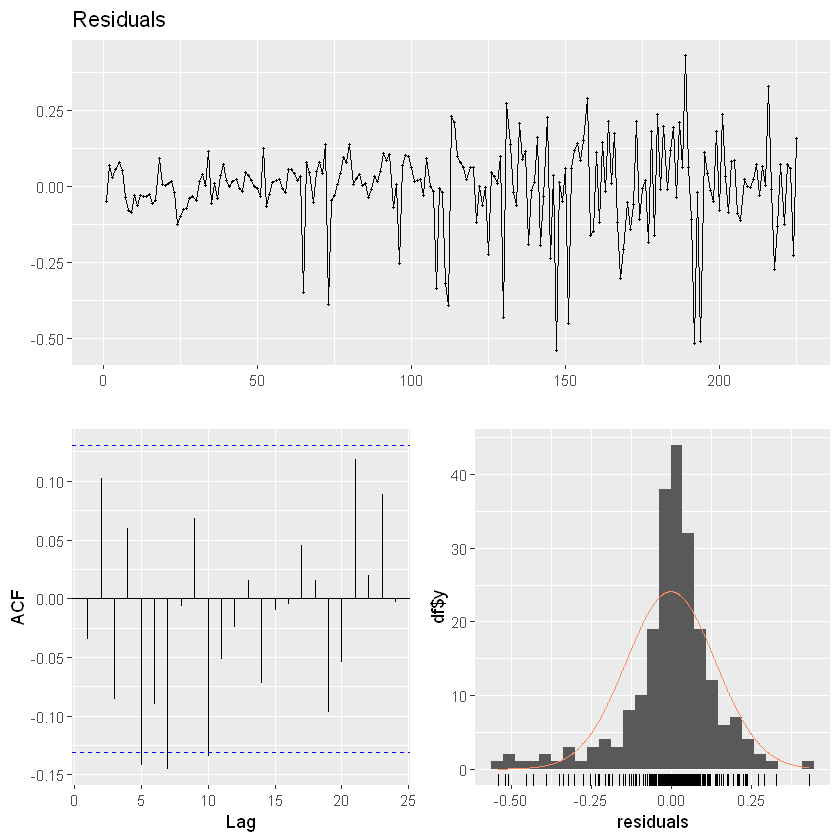

```
[1] "Model Outputs for hour =  13"

Call:
lm(formula = as.formula(fmla[h]), data = dt_train[[h]])

Residuals:
     Min       1Q   Median       3Q      Max
-0.58549 -0.05257  0.02260  0.08032  0.46059

Coefficients:
              Estimate Std. Error t value Pr(>|t|)
(Intercept)  4.3354906  0.7673816   5.650 5.16e-08 ***
RELH         0.0241160  0.0220925   1.092   0.2763
RELH_lag1   -0.0264996  0.0218639  -1.212   0.2269
RELH_lag2    0.0249479  0.0209794   1.189   0.2357
CLL_lag3     0.0009024  0.0016157   0.559   0.5771
RELH_lag3   -0.0112570  0.0163835  -0.687   0.4928
CLL_lag4    -0.0007664  0.0012652  -0.606   0.5453
RELH_lag4   -0.0006469  0.0067568  -0.096   0.9238
RELH_next1   0.0132841  0.0196524   0.676   0.4998
DSWRF_next1  0.0007318  0.0001324   5.526 9.59e-08 ***
RELH_next2  -0.0277535  0.0104798  -2.648   0.0087 **
TEMP_next2  -0.0042543  0.0414328  -0.103   0.9183
TEMP_next3  -0.0084818  0.0417521  -0.203   0.8392
CLL_mean11  -0.0031842  0.0020949  -1.520   0.1300
---
Signif. codes:  0 '***' 0.001 '**' 0.01 '*' 0.05 '.' 0.1 ' ' 1

Residual standard error: 0.1555 on 211 degrees of freedom
Multiple R-squared:  0.6935,	Adjusted R-squared:  0.6746
F-statistic: 36.72 on 13 and 211 DF,  p-value: < 2.2e-16
```

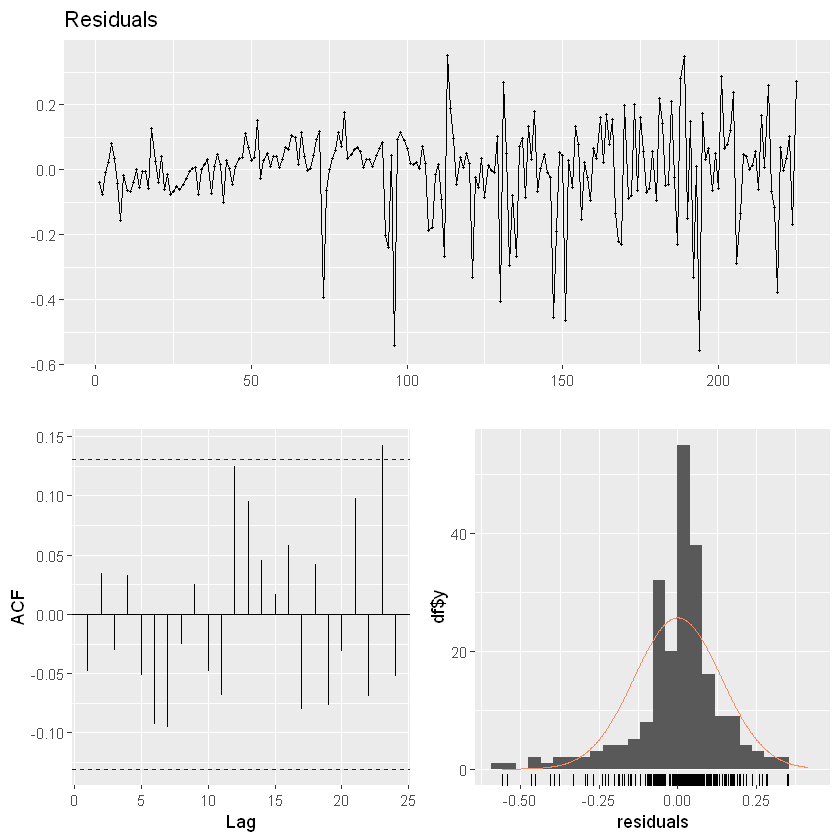

```
[1] "Model Outputs for hour =  14"

Call:
lm(formula = as.formula(fmla[h]), data = dt_train[[h]])

Residuals:
     Min       1Q   Median       3Q      Max
-0.64127 -0.07130  0.01310  0.09498  0.58352

Coefficients:
              Estimate Std. Error t value Pr(>|t|)
(Intercept)  5.7106996  0.8563501   6.669 2.22e-10 ***
RELH         0.0316026  0.0234561   1.347 0.179326
RELH_lag1    0.0080158  0.0251244   0.319 0.750009
RELH_lag2   -0.0370817  0.0247151  -1.500 0.135015
CLL_lag3     0.0115128  0.0060377   1.907 0.057904 .
RELH_lag3    0.0389403  0.0207874   1.873 0.062414 .
CLL_lag4    -0.0082019  0.0052473  -1.563 0.119537
RELH_lag4   -0.0157541  0.0091603  -1.720 0.086930 .
RELH_next1  -0.0202556  0.0175632  -1.153 0.250094
DSWRF_next1  0.0006450  0.0001759   3.666 0.000311 ***
RELH_next2  -0.0125547  0.0075629  -1.660 0.098395 .
TEMP_next2  -0.1009100  0.0436845  -2.310 0.021857 *
TEMP_next3   0.0843090  0.0437893   1.925 0.055532 .
CLL_mean11  -0.0064760  0.0021455  -3.018 0.002854 **
---
Signif. codes:  0 '***' 0.001 '**' 0.01 '*' 0.05 '.' 0.1 ' ' 1

Residual standard error: 0.1784 on 211 degrees of freedom
Multiple R-squared:  0.6765,	Adjusted R-squared:  0.6566
F-statistic: 33.94 on 13 and 211 DF,  p-value: < 2.2e-16
```

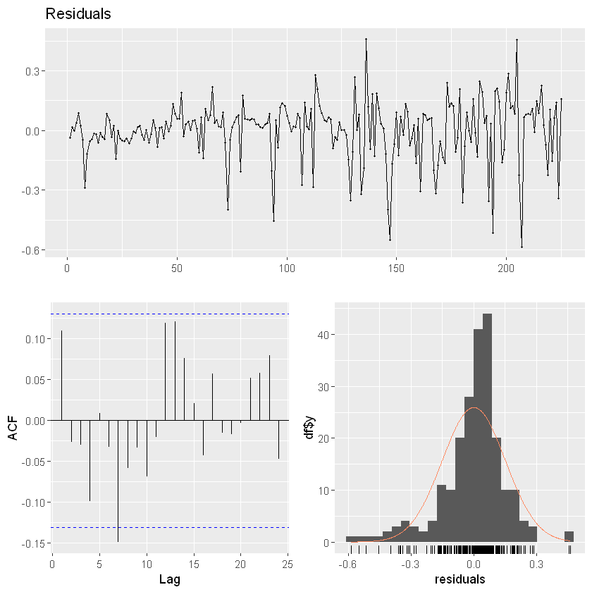

```
[1] "Model Outputs for hour =  15"

Call:
lm(formula = as.formula(fmla[h]), data = dt_train[[h]])

Residuals:
     Min       1Q   Median       3Q      Max
-0.97744 -0.05166  0.03800  0.09875  0.64503

Coefficients:
              Estimate Std. Error t value Pr(>|t|)
(Intercept)  4.9225025  0.9955512   4.944 1.56e-06 ***
RELH        -0.0195814  0.0206894  -0.946  0.34500
RELH_lag1    0.0413798  0.0269136   1.538  0.12567
RELH_lag2   -0.0140317  0.0288133  -0.487  0.62677
CLL_lag3    -0.0200482  0.0092356  -2.171  0.03107 *
RELH_lag3    0.0027614  0.0261124   0.106  0.91588
CLL_lag4     0.0194538  0.0081686   2.382  0.01813 *
RELH_lag4   -0.0059142  0.0115022  -0.514  0.60766
RELH_next1   0.0042505  0.0145175   0.293  0.76998
DSWRF_next1  0.0004732  0.0001763   2.684  0.00786 **
RELH_next2  -0.0136594  0.0075231  -1.816  0.07084 .
TEMP_next2  -0.0351145  0.0204056  -1.721  0.08675 .
TEMP_next3   0.0213984  0.0193544   1.106  0.27015
CLL_mean11  -0.0054210  0.0027245  -1.990  0.04792 *
---
Signif. codes:  0 '***' 0.001 '**' 0.01 '*' 0.05 '.' 0.1 ' ' 1

Residual standard error: 0.2051 on 211 degrees of freedom
Multiple R-squared:  0.6318,	Adjusted R-squared:  0.6091
F-statistic: 27.85 on 13 and 211 DF,  p-value: < 2.2e-16
```

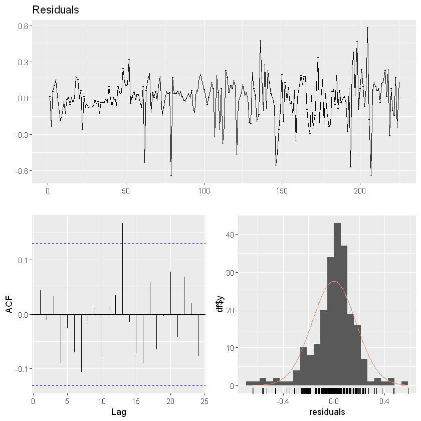

```
[1] "Model Outputs for hour =  16"

Call:
lm(formula = as.formula(fmla[h]), data = dt_train[[h]])

Residuals:
     Min       1Q   Median       3Q      Max
-0.90556 -0.09610  0.01397  0.08789  0.79985

Coefficients:
              Estimate Std. Error t value Pr(>|t|)
(Intercept)  4.0852106  0.8979708   4.549 9.07e-06 ***
RELH        -0.0138557  0.0148640  -0.932   0.3523
RELH_lag1   -0.0024930  0.0208958  -0.119   0.9051
RELH_lag2    0.0191634  0.0270986   0.707   0.4802
CLL_lag3    -0.0056348  0.0079803  -0.706   0.4809
RELH_lag3   -0.0056956  0.0250327  -0.228   0.8202
CLL_lag4     0.0062811  0.0068346   0.919   0.3591
RELH_lag4    0.0014262  0.0124494   0.115   0.9089
RELH_next1   0.0114127  0.0091419   1.248   0.2133
DSWRF_next1  0.0010114  0.0001901   5.319 2.65e-07 ***
RELH_next2  -0.0093934  0.0047958  -1.959   0.0515 .
TEMP_next2   0.0327506  0.0191800   1.708   0.0892 .
TEMP_next3  -0.0458114  0.0189955  -2.412   0.0167 *
CLL_mean11  -0.0048623  0.0026389  -1.843   0.0668 .
---
Signif. codes:  0 '***' 0.001 '**' 0.01 '*' 0.05 '.' 0.1 ' ' 1

Residual standard error: 0.2067 on 211 degrees of freedom
Multiple R-squared:  0.583,	Adjusted R-squared:  0.5573
F-statistic: 22.69 on 13 and 211 DF,  p-value: < 2.2e-16
```

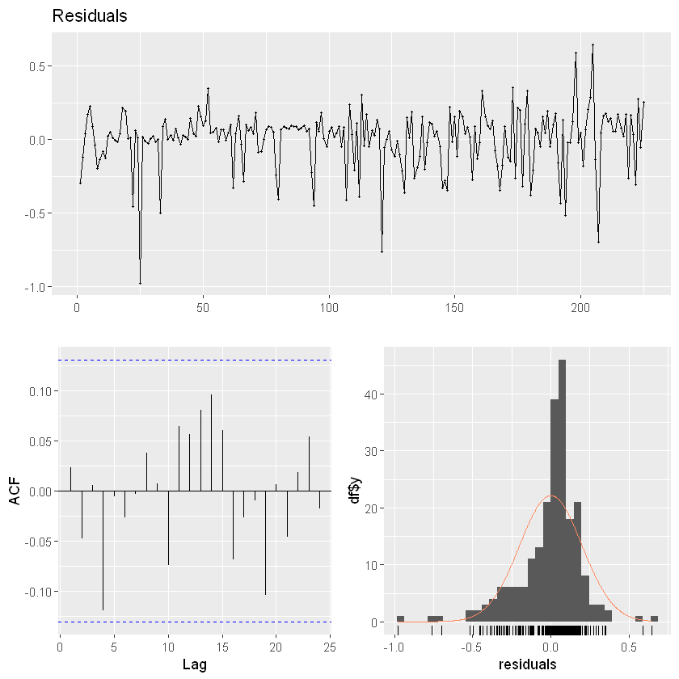

```
[1] "Model Outputs for hour =  17"

Call:
lm(formula = as.formula(fmla[h]), data = dt_train[[h]])

Residuals:
     Min       1Q   Median       3Q      Max
-0.84867 -0.08567 -0.00060  0.09060  0.56596

Coefficients:
              Estimate Std. Error t value Pr(>|t|)
(Intercept)  5.7576643  0.9674004   5.952 1.09e-08 ***
RELH         0.0024058  0.0091807   0.262   0.7935
RELH_lag1    0.0051823  0.0146102   0.355   0.7232
RELH_lag2   -0.0329105  0.0201723  -1.631   0.1043
CLL_lag3     0.0094621  0.0095054   0.995   0.3207
RELH_lag3    0.0581502  0.0242114   2.402   0.0172 *
CLL_lag4    -0.0071169  0.0083582  -0.851   0.3955
RELH_lag4   -0.0242280  0.0126350  -1.918   0.0565 .
RELH_next1   0.0030847  0.0083124   0.371   0.7109
DSWRF_next1  0.0016810  0.0002571   6.538 4.61e-10 ***
RELH_next2  -0.0077300  0.0044904  -1.721   0.0866 .
TEMP_next2   0.0290414  0.0299757   0.969   0.3337
TEMP_next3  -0.0493326  0.0310557  -1.589   0.1137
CLL_mean11  -0.0061578  0.0024490  -2.514   0.0127 *
---
Signif. codes:  0 '***' 0.001 '**' 0.01 '*' 0.05 '.' 0.1 ' ' 1

Residual standard error: 0.1988 on 211 degrees of freedom
Multiple R-squared:  0.6152,	Adjusted R-squared:  0.5915
F-statistic: 25.95 on 13 and 211 DF,  p-value: < 2.2e-16
```

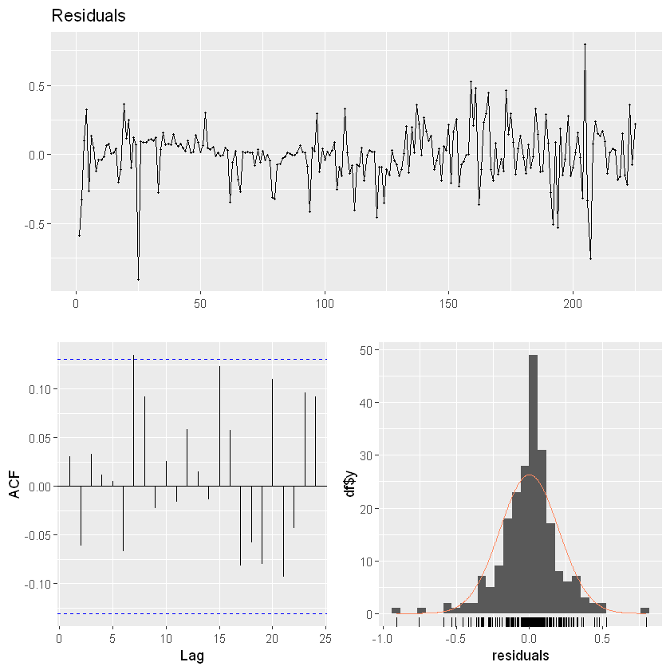

```
[1] "Model Outputs for hour =  18"

Call:
lm(formula = as.formula(fmla[h]), data = dt_train[[h]])

Residuals:
     Min       1Q   Median       3Q      Max
-0.70976 -0.07311  0.00059  0.06794  0.59653

Coefficients:
              Estimate Std. Error t value Pr(>|t|)
(Intercept)  6.9336285  1.3175077   5.263 5.17e-07 ***
RELH         0.0228259  0.0085541   2.668  0.00851 **
RELH_lag1    0.0174407  0.0110565   1.577  0.11694
RELH_lag2   -0.0486639  0.0203400  -2.393  0.01805 *
CLL_lag3     0.0416741  0.0183050   2.277  0.02431 *
RELH_lag3    0.0250356  0.0271558   0.922  0.35814
CLL_lag4    -0.0387790  0.0159109  -2.437  0.01604 *
RELH_lag4    0.0094124  0.0166304   0.566  0.57231
RELH_next1  -0.0177655  0.0110769  -1.604  0.11099
DSWRF_next1  0.0038474  0.0002945  13.066  < 2e-16 ***
RELH_next2  -0.0020016  0.0071936  -0.278  0.78123
TEMP_next2  -0.1104425  0.0635491  -1.738  0.08441 .
TEMP_next3   0.0835623  0.0636065   1.314  0.19107
CLL_mean11  -0.0022338  0.0038400  -0.582  0.56169
---
Signif. codes:  0 '***' 0.001 '**' 0.01 '*' 0.05 '.' 0.1 ' ' 1

Residual standard error: 0.1819 on 141 degrees of freedom
Multiple R-squared:  0.7693,	Adjusted R-squared:  0.748
F-statistic: 36.17 on 13 and 141 DF,  p-value: < 2.2e-16
```

[3 more figures not shown]

```r
formulas <- rep("scaledprod ~ .-date-datetime-hour-capacity-production-TEMP-TEMP_lag1-TEMP_lag2-TEMP_lag3-TEMP_lag4-TEMP_above-RELH_next3-TEMP_next1-CLL_next1-CLL_next2-scaledprod_lag72-CLL_lag2-RELH_l8h-DSWRF_next2-RELH_mean11-production-CLL_lag1-scaledprod_lag96-scaledprod_lag120-DSWRF_next3-CLL-CLL_next3-DSWRF_above-TEMP_above-RELH_above-CLL_above-DSWRF-DSWRF_lag1-DSWRF_lag2-DSWRF_lag3-DSWRF_lag4", 23)
test_results <- forecast_with_lr(formulas, dt_hour, "2022-03-01", "2022-06-01", dt)
```

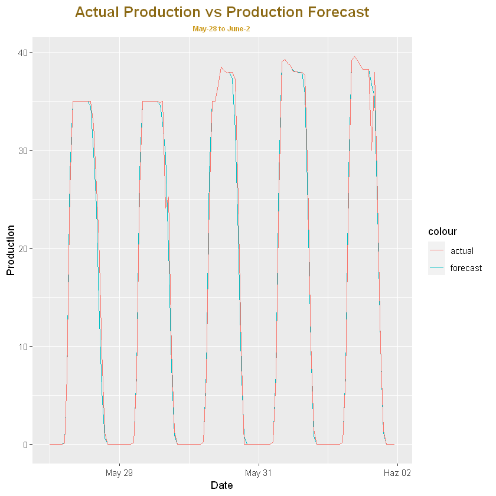

```r
ggplot(tail(test_results,120), aes(x=datetime))+ geom_line(aes(y=forecast, color= "forecast"))+ geom_line(aes(y=actual , color="actual")) +
 labs(title = "Actual Production vs Production Forecast", x = "Date",y = "Production",subtitle = "May-28 to June-2")+
  theme(plot.title = element_text(color = "goldenrod4", size = 15, face = "bold",hjust=0.5),
  plot.subtitle = element_text(size = 7,color="goldenrod3", face = "bold", hjust = 0.5) )
```

# Conclusion and Future Work

Our final model has a very low WMAPE by the test results, and the model provided a total WMAPE of 0.109 for the competition phase (May 25 to June 23). However, improvements and further corrective actions are possible.

First, instead of fitting a model for 12 pm and choosing the best values, one could construct models for each hour and repeat the improvement steps for these models. This would require much more computational time and effort, yet; might not prove to be worthy at the end for close hours (models for 12 pm, 13 pm and 14 pm would show pretty similar characteristics for instance). Another approach could be dividing the data into several parts consisting of 4 to 6 hours and trying different models for each part, this time model variables are the same for different hours within the same sub-part.

Moreover, these models are constructed such that predictions for June, July and August at most can be made. Cutting a great portion of the dataset would prevent us from predicting future productions in Fall or other seasons. Regardless of the length of the dataset, WMAPE would increase due to increasing variability. However; one could use related portion of the dataset as well. For instance, if we were to make predictions for November 2022, training the data on the Fall of 2021 could prove to be more practical.

Most of the features are removed due to correlations between variables. These kind of prediction making procedures involve high levels of interrelation in terms of attributes and one might anaylze the variables more elaborately for further predictions. Model imperfections result not only from variable relations, but also production data itself. There are no visible patterns, seasonalities or trends for most of the hours.

# Appendices

##### The Jupyter notebook used for retrieving data and making submissions is [here](https://github.com/BU-IE-360/spring22-bthnsrts/blob/gh-pages/IE360%20Project/360Project_Code.ipynb). (.ipynb file)

##### The data (.csv files) used in these files are [here](https://github.com/BU-IE-360/spring22-bthnsrts/blob/gh-pages/IE360%20Project/2022-06-07_production_weather.zip). (.zip file)

# References

Daily downward surface shortwave flux (DIDSSF, LSA-203). DIDSSF - Daily Downward Surface Shortwave Flux. (n.d.). Retrieved June 3, 2022, from https://landsaf.ipma.pt/en/products/longwave-shortwave-radiation/didssf/#:~:text=The%20Downward%20Surface%20Shortwave%20Flux,atmospheric%20absorption%20and%20surface%20albedo.